# 1120 Data Analysis

Michelle K Jamieson

25/08/2020

# 1 Introduction to the Data

```r
# load libraries
pacman::p_load(gmodels,
               skimr,
               knitr,
               tidyverse,
               haven,
               psych,
               dplyr,
               synthpop,
               dataMaid,
               Hmisc,
               ggplot2)
```

The `haven` package can import datasets created by SPSS and a number other programs such as Stata and SAS.

There are a few features of SPSS datasets that require special handling when loading data into R. SPSS files often contain variables with both character labels and numeric codes that are not necessarily sequential (e.g. for the variable ‘ever been in paid employment’, 1 = item not applicable, 2 = yes, 3 = no, 4 = don’t know, 5 = no answer/refused). SPSS also allows variables to have multiple, user-defined missing values. This sort of variable metadata is helpful, but it doesn’t quite align with any of R’s standard data types.

The `haven` package handles these differences by importing variables in a custom format called `labelled` and leaving the user to decide which of the numeric codes or value labels he or she wants to work with in R.

We’ll import the data using `haven’s` `read_sav()` function. We’ll set `user_na = TRUE` to ensure that responses such as “Don’t know” or “Refused” aren’t automatically converted to missing values. In this case, we also want to convert any labelled variables into factors so that we can work with value labels instead of the numeric codes (e.g. “yes” instead of “1”). We do this by piping `(%>%)` the entire dataset to `haven's` `as_factor()` function which converts any labelled variables in the dataset to factors.

```r
source_pms07 <- haven::read_sav("pms07.sav",
                  user_na = TRUE) %>%
  as_factor()
```

## 1.2 Subsetting the data

All original variables within the 2007 PMS we’re interested in.

```r
# Subsetting to manage descriptive, work,
# and health variables
subset_pms07 <- source_pms07 %>%
  dplyr::select("pserial","ResSex","Health6","Language","Age10yr","Age20yr",
                "ETHNIC4",
                "Origin","EDQUAL5","AnyQuals","HiQuals","ResMarDF",
                "DVILO3a","DVPrac","Care1","Care2","Care3","Care4",
                "Care5","Everwk","yearjbl","JbReas","Looked",
                "YInAct","LookStop","LookSto2","Stat","Solo",
                "HrsWeek","PTWkHour","EmpStY","LookNot1","LookNot2",
                "LookNot3","DVLastWk","NotWk","WkShel1","HrsWork",
                "LookSto3","DiffJob","WkShel2","WkShel3","SEmpStY",
                "LookNow","LookAtAl","JobstM","EmpNo","Manage",
                "FtPtWk","NotWk","SEG","SC","SrcInc1","SrcInc2",
                "SrcInc3","SrcInc4","SrcInc5","SrcInc6","Gross4",
                "Gross4a","Ten1","LLord","SF6","SF7","SF9","SF11",
                "SF12","CONHOMD","IMon","FollUpGrp",
                "eligible","Stage2","Origin","DVPrac","Care1","Care2",
                "Care3","Care4","Care5","Medic","CnslHav","CnslTak",
                "CnslLng","DocYear","DocPsyc","PMatNum","DocTalk",
                "DocWeeks","InWhy","OutWhy","DayY","DayWht1",
                "DayWht2","DayWht3","DayWht4","CC2aY",
                "CC2Y1","CC2Y2","CC2Y3","CC2Y5","CC2Y6","CC2Y7",
                "CC2Y8","CC2Y9","MentHos","Ten1","Gross4a","qimd",
                "gor06","newsha","SF1","Happy","tenure","newten",
                "hhdtype","DISsex","DISeth","DISrel","DISAge",
                "DISmen","DISphy",
                "DISsori","CISRFOUR","panic","GAD","madd","OCD",
                "phob","dep","neurotic","nosymp","numdis",
                "PTSDever","MajorT16","PTSDcom","PTSDPos",
                "suicthwk","suicthyr","suicthlf","DSHlife",
                "suicatwk","suicatyr","suicatlf","DSHtry","suihfri",
                "suihhos","suihcom","suihhel","suihoth","DSH5",
                "DSHharm","DSH9","DSH10","PsycProb","Psycdis",
                "Psycdis_wt","BPDPH2","bdpd_wt","ASPDPH2","aspd_wt",
                "DVADHD1","DVADHD2","DVADHD4","scoff2","EDImpact",
                "bmigp4","DVAudit1","AUDITgp","DRNKPROB","SADQCSC",
                "SADQGP","AUDSAD2","Cannever","Cannyear","AMPHEVER",
                "AMPHYEAR","COCAEVER","CRACEVER","CRACYEAR",
                "ECSTEVER","ECSTYEAR","HEROEVER","HEROYEAR",
                "ACIDEVER","ACIDYEAR","MUSHEVER","MUSHYEAR",
                "METHEVER","METHYEAR","TRANEVER","TRANYEAR",
                "AMYLEVER","AMYLYEAR","ANABEVER",
                "ANABYEAR","GLUEEVER","GLUEYEAR","DRUGEVER",
                "DRUGYEAR","DRUGDEP",
                "DRUGDEP2","GamYR","dsmscgr","dsmprob","dsmpath",
                "numdiag","numdiag4","LCA","cluster1","cluster2",
                "cluster3","cluster4","cluster5","cluster6",
                "MedPsyc","MedDep","MedHyp","MedAnx","MedADHD",
                "anymed","Doc2Wks","DocPsyc","INQTRMEN","OUTQTRME",
                "PSYCTHER","COGTHER","ARTTHER","SOCTRAIN","MARITHER"
                ,"SEXTHER","COUNSEL","OTHTHER","OTHTHER","anyther",
                "trtment","DAYCOMYR","PSYTRTYR","PSYLGTYR",
                "CPNYR","CLDNYR","OTHNSEYR","SOCWRKYR","CPNYR",
                "ERI3","SFQA","SFQB","SFQC","SFQD",
                "SFQE","SFQF","SFQG","SFQH","DLSS4","DLSS5",
                "PrimGrp","ChldInst","LACare","BothMaPa",
                "YNotBoth","MaOrPa","AnyChild","NoChild",
                "InDebt1","InDebt6",
                "SFHELPYR","HMHELPYR","OREACHYR","anyccar","anyhlca"
                ,"anydaca","wt_ints1","ipsu_0714","istrata_0714")

head(subset_pms07, 5)
```

| pserial | ResSex | Health6 | Language | Age10yr | Age20yr | ETHNIC4 | Origin | EDQUAL5 | AnyQuals | HiQuals | ResMarDF | DVILO3a | DVPrac | Care1 | Care2 | Care3 | Care4 | Care5 | Everwk | yearjbl | JbReas | Looked | YInAct | LookStop | LookSto2 | Stat | Solo | HrsWeek | PTWkHour | … |
| --- | --- | --- | --- | --- | --- | --- | --- | --- | --- | --- | --- | --- | --- | --- | --- | --- | --- | --- | --- | --- | --- | --- | --- | --- | --- | --- | --- | --- | --- | --- |
| 11103072 | Female | Mentioned | Yes | 45 - 54 | 35 - 54 | White | White - British | No qualifications | No | Item not applicable | Cohabiting | In employment or unpaid family worker | 0 | No | Item not applicable | Item not applicable | Item not applicable | Item not applicable | Item not applicable | Item not applicable | Item not applicable | Item not applicable | Item not applicable | Item not applicable | Item not applicable | Employee | Item not applicable | Item not applicable | Item not applicable | … |
| 11103102 | Female | Not mentioned | Yes | 75+ | 75+ | White | White - British | No qualifications | No | Item not applicable | Divorced | Economically inactive | 3 | No | Item not applicable | Item not applicable | Item not applicable | Item not applicable | Yes | 1988 | Item not applicable | No | Retired from paid work | Item not applicable | Item not applicable | Employee | Item not applicable | Item not applicable | Item not applicable | … |
| 11103112 | Female | Mentioned | Yes | 45 - 54 | 35 - 54 | White | White - British | GCSE or equivalent | Yes | O Level passes (Grade A-C if after 1975) | Single | In employment or unpaid family worker | 0 | No | Item not applicable | Item not applicable | Item not applicable | Item not applicable | Item not applicable | Item not applicable | Item not applicable | Item not applicable | Item not applicable | Item not applicable | Item not applicable | Employee | Item not applicable | Item not applicable | Item not applicable | … |
| 11103132 | Female | Not mentioned | Yes | 55 - 64 | 55 - 74 | Mixed or other | Any other (please describe) | A Level | Yes | A levels/SCE Higher,ONC/OND/TEC not higher | Married | In employment or unpaid family worker | 2 | No | Item not applicable | Item not applicable | Item not applicable | Item not applicable | Item not applicable | Item not applicable | Item not applicable | Item not applicable | Item not applicable | Item not applicable | Item not applicable | Employee | Item not applicable | Item not applicable | 30 | … |
| 11103162 | Male | Not mentioned | Yes | 65 - 74 | 55 - 74 | White | White - British | Degree | Yes | Degree level qualification | Divorced | Economically inactive | 0 | No | Item not applicable | Item not applicable | Item not applicable | Item not applicable | Yes | 2006 | Item not applicable | No | Retired from paid work | Item not applicable | Item not applicable | Employee | Item not applicable | Item not applicable | 12 | … |

## 1.3 Viewing the Data

A nice way to view the subsetted dataset.

```r
# view
#subset_pms07 %>% sjPlot::view_df()# no longer needed
# makeCodebook now works after reading in
# .csv with as.factor()
#makeCodebook(subset_pms07, vol = "10",
#             reportTitle = NULL, file = NULL)

glimpse(subset_pms07)
```

```
## Rows: 7,403
## Columns: 260
## $ pserial      <fct> 11103072, 11103102, 11103112, 11103132, 11103162, 1110...
## $ ResSex       <fct> Female, Female, Female, Female, Male, Male, Female, Ma...
## $ Health6      <fct> Mentioned, Not mentioned, Mentioned, Not mentioned, No...
## $ Language     <fct> Yes, Yes, Yes, Yes, Yes, Yes, Yes, Yes, Yes, No, Yes, ...
## $ Age10yr      <fct> 45 - 54, 75+, 45 - 54, 55 - 64, 65 - 74, 75+, 75+, 35 ...
## $ Age20yr      <fct> 35 - 54, 75+, 35 - 54, 55 - 74, 55 - 74, 75+, 75+, 35 ...
## $ ETHNIC4      <fct> "White", "White", "White", "Mixed or other", "White", ...
## $ Origin       <fct> White - British, White - British, White - British, Any...
## $ EDQUAL5      <fct> "No qualifications", "No qualifications", "GCSE or equ...
## $ AnyQuals     <fct> No, No, Yes, Yes, Yes, No, Yes, Yes, Yes, Yes, Yes, Ye...
## $ HiQuals      <fct> "Item not applicable", "Item not applicable", "O Level...
## $ ResMarDF     <fct> Cohabiting, Divorced, Single, Married, Divorced, Marri...
## $ DVILO3a      <fct> In employment or unpaid family worker, Economically in...
```

[output cut: 247 more lines]

# 2 Understanding the Subset

Getting to grips with what’s in the variables will help decide on meaningful analysis later on.

```r
subset_pms07 %>%
  distinct(ResSex)
```

| ResSex |
| --- |
| Female |
| Male |

```r
subset_pms07 %>%
  distinct(Age10yr)
```

| Age10yr |
| --- |
| 45 - 54 |
| 75+ |
| 55 - 64 |
| 65 - 74 |
| 35 - 44 |
| 25 - 34 |
| 16 - 24 |

```r
subset_pms07 %>%
  distinct(SF1)
```

| SF1 |
| --- |
| very good |
| fair |
| good |
| or, poor? |
| Excellent |
| No answer/refused |
| Don't know |

```r
subset_pms07 %>%
  distinct(Happy)
```

| Happy |
| --- |
| Very happy |
| Fairly happy |
| Not too happy |
| Don't know |

```r
subset_pms07 %>%
  distinct(Everwk)
```

| Everwk |
| --- |
| Item not applicable |
| Yes |
| No |
| Don't know |
| No answer/refused |

```r
subset_pms07 %>%
  distinct(Psycdis)
```

| Psycdis |
| --- |
| No |
| Yes |
| Item not applicable |

# 3 Cleaning Subset

## 3.1 Re-Coding Names

Making the variables easier to understand.

```r
# look at variable names
colnames(subset_pms07)
```

```
##   [1] "pserial"      "ResSex"       "Health6"      "Language"     "Age10yr"
##   [6] "Age20yr"      "ETHNIC4"      "Origin"       "EDQUAL5"      "AnyQuals"
##  [11] "HiQuals"      "ResMarDF"     "DVILO3a"      "DVPrac"       "Care1"
##  [16] "Care2"        "Care3"        "Care4"        "Care5"        "Everwk"
##  [21] "yearjbl"      "JbReas"       "Looked"       "YInAct"       "LookStop"
##  [26] "LookSto2"     "Stat"         "Solo"         "HrsWeek"      "PTWkHour"
##  [31] "EmpStY"       "LookNot1"     "LookNot2"     "LookNot3"     "DVLastWk"
##  [36] "NotWk"        "WkShel1"      "HrsWork"      "LookSto3"     "DiffJob"
##  [41] "WkShel2"      "WkShel3"      "SEmpStY"      "LookNow"      "LookAtAl"
##  [46] "JobstM"       "EmpNo"        "Manage"       "FtPtWk"       "SEG"
##  [51] "SC"           "SrcInc1"      "SrcInc2"      "SrcInc3"      "SrcInc4"
##  [56] "SrcInc5"      "SrcInc6"      "Gross4"       "Gross4a"      "Ten1"
##  [61] "LLord"        "SF6"          "SF7"          "SF9"          "SF11"
##  [66] "SF12"         "CONHOMD"      "IMon"         "FollUpGrp"    "eligible"
##  [71] "Stage2"       "Medic"        "CnslHav"      "CnslTak"      "CnslLng"
```

[output cut: 37 more lines]

```r
# rename variables for easier reading
subset_pms07 <- subset_pms07 %>%
  rename(GenHeal = SF1,
         Paidwk = Everwk,
         DefPsych = Psycdis,
         Sex = ResSex,
         EthnicGrp = ETHNIC4,
         HiEduQualGrp = EDQUAL5,
         MariStat = ResMarDF,
         EmpStatGrp = DVILO3a,
         DaLivHelp = DVPrac,
         LeftJob = yearjbl,
         JobReas = JbReas,
         LookWk4 = Looked,
         NotLookWk = YInAct,
         Working = Stat,
         WkSolo = Solo,
         TimeLWk = DVLastWk,
         NotWkRea = NotWk,
         SocEcGrp = SEG,
         SocCl = SC,
         LessWkEmo = SF6,
         LessCarEmo = SF7,
         FelCal = SF9,
         FelDownH = SF11,
         ProbInter = SF12,
         PosEx = CONHOMD,
         CurMeds = Medic,
         ComCaYr = CC2aY,
         ComCaPsychi = CC2Y1,
         CommCaPsychol = CC2Y2,
         ComCarCPN = CC2Y3,
         ComCarON = CC2Y5,
         ComCarSW = CC2Y6,
         ComCaSHGrp = CC2Y7,
         ComCaHH = CC2Y8,
         ComCaOW = CC2Y9,
         GenHeal = SF1
         )

# check it worked
colnames(subset_pms07)
```

```
##   [1] "pserial"       "Sex"           "Health6"       "Language"
##   [5] "Age10yr"       "Age20yr"       "EthnicGrp"     "Origin"
##   [9] "HiEduQualGrp"  "AnyQuals"      "HiQuals"       "MariStat"
##  [13] "EmpStatGrp"    "DaLivHelp"     "Care1"         "Care2"
##  [17] "Care3"         "Care4"         "Care5"         "Paidwk"
##  [21] "LeftJob"       "JobReas"       "LookWk4"       "NotLookWk"
##  [25] "LookStop"      "LookSto2"      "Working"       "WkSolo"
##  [29] "HrsWeek"       "PTWkHour"      "EmpStY"        "LookNot1"
##  [33] "LookNot2"      "LookNot3"      "TimeLWk"       "NotWkRea"
##  [37] "WkShel1"       "HrsWork"       "LookSto3"      "DiffJob"
##  [41] "WkShel2"       "WkShel3"       "SEmpStY"       "LookNow"
##  [45] "LookAtAl"      "JobstM"        "EmpNo"         "Manage"
##  [49] "FtPtWk"        "SocEcGrp"      "SocCl"         "SrcInc1"
##  [53] "SrcInc2"       "SrcInc3"       "SrcInc4"       "SrcInc5"
##  [57] "SrcInc6"       "Gross4"        "Gross4a"       "Ten1"
```

[output cut: 50 more lines]

# 4 Descriptive Statistics

## 4.1 Overall Age, Sex, General Employment and Mental Health

There are 7,403 respondants within the PMS 2007 dataset.

```r
skim(subset_pms07$pserial)
```

Data summary

| Name | subset_pms07$pserial |
| --- | --- |
| Number of rows | 7403 |
| Number of columns | 1 |
| _______________________ |  |
| Column type frequency: |  |
| factor | 1 |
| ________________________ |  |
| Group variables | None |

**Variable type: factor**

| skim_variable | n_missing | complete_rate | ordered | n_unique | top_counts |
| --- | --- | --- | --- | --- | --- |
| data | 0 | 1 | FALSE | 7403 | 111: 1, 111: 1, 111: 1, 111: 1 |

```r
(as.data.frame(table(subset_pms07$Age10yr))
  %>% rename(Count=1,Freq=2) %>% mutate(Perc=100*Freq/sum(Freq)))
```

| Count | Freq | Perc |
| --- | --- | --- |
| No answer/refused | 0 | 0.000000 |
| Don't know | 0 | 0.000000 |
| Missing data | 0 | 0.000000 |
| Proxy | 0 | 0.000000 |
| Item not applicable | 0 | 0.000000 |
| 16 - 24 | 568 | 7.672565 |
| 25 - 34 | 1035 | 13.980819 |
| 35 - 44 | 1413 | 19.086857 |
| 45 - 54 | 1130 | 15.264082 |
| 55 - 64 | 1279 | 17.276780 |

[output cut: 2 more lines]

```r
(as.data.frame(table(subset_pms07$Sex))
  %>% rename(Count=1,Freq=2) %>% mutate(Perc=100*Freq/sum(Freq)))
```

| Count | Freq | Perc |
| --- | --- | --- |
| No answer/refused | 0 | 0.0000 |
| Don't know | 0 | 0.0000 |
| Missing data | 0 | 0.0000 |
| Proxy | 0 | 0.0000 |
| Item not applicable | 0 | 0.0000 |
| Male | 3197 | 43.1852 |
| Female | 4206 | 56.8148 |

```r
(as.data.frame(table(subset_pms07$Paidwk))
  %>% rename(Count=1,Freq=2) %>% mutate(Perc=100*Freq/sum(Freq)))
```

| Count | Freq | Perc |
| --- | --- | --- |
| No answer/refused | 7 | 0.09455626 |
| Don't know | 38 | 0.51330542 |
| Missing data | 0 | 0.00000000 |
| Proxy | 0 | 0.00000000 |
| Schedule not applicable | 0 | 0.00000000 |
| Item not applicable | 3989 | 53.88356072 |
| Yes | 3073 | 41.51019857 |
| No | 296 | 3.99837904 |

```r
(as.data.frame(table(subset_pms07$Health6))
  %>% rename(Count=1,Freq=2) %>% mutate(Perc=100*Freq/sum(Freq)))
```

| Count | Freq | Perc |
| --- | --- | --- |
| No answer/refused | 3 | 0.04052411 |
| Don't know | 0 | 0.00000000 |
| Missing data | 0 | 0.00000000 |
| Proxy | 0 | 0.00000000 |
| Schedule not applicable | 0 | 0.00000000 |
| Item not applicable | 0 | 0.00000000 |
| Not mentioned | 5686 | 76.80669999 |
| Mentioned | 1714 | 23.15277590 |

## 4.2 Non-Severe Mental Illness

The term NSMI refers to a set of illness’ that are much more common in the general population, and include, depression (including subthreshold disorders) and, anxiety disorders (including GAD, panic disorder, phobias, social anxiety disorder, OCD and PTSD) (NICE, 2019)

## 4.3 Respondant Sex Variable

So this table tells us that 43.1% and 56.8% of the sample are male and female respectively, which sounds pretty reasonable.

```r
# prop
prop.table(table(subset_pms07$Sex))
```

```
##
##   No answer/refused          Don't know        Missing data               Proxy
##            0.000000            0.000000            0.000000            0.000000
## Item not applicable                Male              Female
##            0.000000            0.431852            0.568148
```

## 4.4 Age Respondant Variable

The next step is to see if any age groups are over or under-represented in either of the genders. I’m going to use the package gmodels to produce these cross-tables:

```r
CrossTable(subset_pms07$Age10yr,
          subset_pms07$Sex,prop.r=FALSE,prop.t=FALSE,
          prop.chisq=FALSE)
```

```
##
##
##    Cell Contents
## |-------------------------|
## |                       N |
## |           N / Col Total |
## |-------------------------|
##
##
## Total Observations in Table:  7403
##
##
##                      | subset_pms07$Sex
## subset_pms07$Age10yr |      Male |    Female | Row Total |
## ---------------------|-----------|-----------|-----------|
##              16 - 24 |       271 |       297 |       568 |
##                      |     0.085 |     0.071 |           |
## ---------------------|-----------|-----------|-----------|
##              25 - 34 |       414 |       621 |      1035 |
##                      |     0.129 |     0.148 |           |
## ---------------------|-----------|-----------|-----------|
##              35 - 44 |       613 |       800 |      1413 |
##                      |     0.192 |     0.190 |           |
## ---------------------|-----------|-----------|-----------|
##              45 - 54 |       495 |       635 |      1130 |
##                      |     0.155 |     0.151 |           |
## ---------------------|-----------|-----------|-----------|
##              55 - 64 |       573 |       706 |      1279 |
##                      |     0.179 |     0.168 |           |
## ---------------------|-----------|-----------|-----------|
##              65 - 74 |       462 |       566 |      1028 |
##                      |     0.145 |     0.135 |           |
## ---------------------|-----------|-----------|-----------|
##                  75+ |       369 |       581 |       950 |
##                      |     0.115 |     0.138 |           |
## ---------------------|-----------|-----------|-----------|
##         Column Total |      3197 |      4206 |      7403 |
##                      |     0.432 |     0.568 |           |
## ---------------------|-----------|-----------|-----------|
##
##
```

## 4.5 General Employment

```r
# by age
CrossTable(subset_pms07$Paidwk,
          subset_pms07$Age20yr,prop.r=FALSE,prop.t=FALSE,
          prop.chisq=FALSE)
```

```
##
##
##    Cell Contents
## |-------------------------|
## |                       N |
## |           N / Col Total |
## |-------------------------|
##
##
## Total Observations in Table:  7403
##
##
##                     | subset_pms07$Age20yr
## subset_pms07$Paidwk |   16 - 34 |   35 - 54 |   55 - 74 |       75+ | Row Total |
## --------------------|-----------|-----------|-----------|-----------|-----------|
##   No answer/refused |         1 |         1 |         2 |         3 |         7 |
##                     |     0.001 |     0.000 |     0.001 |     0.003 |           |
## --------------------|-----------|-----------|-----------|-----------|-----------|
##          Don't know |        10 |         9 |         5 |        14 |        38 |
##                     |     0.006 |     0.004 |     0.002 |     0.015 |           |
## --------------------|-----------|-----------|-----------|-----------|-----------|
## Item not applicable |      1124 |      2018 |       828 |        19 |      3989 |
##                     |     0.701 |     0.794 |     0.359 |     0.020 |           |
## --------------------|-----------|-----------|-----------|-----------|-----------|
##                 Yes |       301 |       472 |      1427 |       873 |      3073 |
##                     |     0.188 |     0.186 |     0.619 |     0.919 |           |
## --------------------|-----------|-----------|-----------|-----------|-----------|
##                  No |       167 |        43 |        45 |        41 |       296 |
##                     |     0.104 |     0.017 |     0.020 |     0.043 |           |
## --------------------|-----------|-----------|-----------|-----------|-----------|
##        Column Total |      1603 |      2543 |      2307 |       950 |      7403 |
##                     |     0.217 |     0.344 |     0.312 |     0.128 |           |
## --------------------|-----------|-----------|-----------|-----------|-----------|
##
##
```

```r
# by sex
CrossTable(subset_pms07$Paidwk,
          subset_pms07$Sex,prop.r=FALSE,prop.t=FALSE,
          prop.chisq=FALSE)
```

```
##
##
##    Cell Contents
## |-------------------------|
## |                       N |
## |           N / Col Total |
## |-------------------------|
##
##
## Total Observations in Table:  7403
##
##
##                     | subset_pms07$Sex
## subset_pms07$Paidwk |      Male |    Female | Row Total |
## --------------------|-----------|-----------|-----------|
##   No answer/refused |         3 |         4 |         7 |
##                     |     0.001 |     0.001 |           |
## --------------------|-----------|-----------|-----------|
##          Don't know |        17 |        21 |        38 |
##                     |     0.005 |     0.005 |           |
## --------------------|-----------|-----------|-----------|
## Item not applicable |      1934 |      2055 |      3989 |
##                     |     0.605 |     0.489 |           |
## --------------------|-----------|-----------|-----------|
##                 Yes |      1153 |      1920 |      3073 |
##                     |     0.361 |     0.456 |           |
## --------------------|-----------|-----------|-----------|
##                  No |        90 |       206 |       296 |
##                     |     0.028 |     0.049 |           |
## --------------------|-----------|-----------|-----------|
##        Column Total |      3197 |      4206 |      7403 |
##                     |     0.432 |     0.568 |           |
## --------------------|-----------|-----------|-----------|
##
##
```

```r
# by reported mh cond
CrossTable(subset_pms07$Paidwk,
          subset_pms07$Health6,prop.r=FALSE,prop.t=FALSE,
          prop.chisq=FALSE)
```

```
##
##
##    Cell Contents
## |-------------------------|
## |                       N |
## |           N / Col Total |
## |-------------------------|
##
##
## Total Observations in Table:  7403
##
##
##                     | subset_pms07$Health6
## subset_pms07$Paidwk | No answer/refused |     Not mentioned |         Mentioned |         Row Total |
## --------------------|-------------------|-------------------|-------------------|-------------------|
##   No answer/refused |                 0 |                 6 |                 1 |                 7 |
##                     |             0.000 |             0.001 |             0.001 |                   |
## --------------------|-------------------|-------------------|-------------------|-------------------|
##          Don't know |                 0 |                28 |                10 |                38 |
##                     |             0.000 |             0.005 |             0.006 |                   |
## --------------------|-------------------|-------------------|-------------------|-------------------|
## Item not applicable |                 0 |              3113 |               876 |              3989 |
##                     |             0.000 |             0.547 |             0.511 |                   |
## --------------------|-------------------|-------------------|-------------------|-------------------|
##                 Yes |                 3 |              2295 |               775 |              3073 |
##                     |             1.000 |             0.404 |             0.452 |                   |
## --------------------|-------------------|-------------------|-------------------|-------------------|
##                  No |                 0 |               244 |                52 |               296 |
##                     |             0.000 |             0.043 |             0.030 |                   |
## --------------------|-------------------|-------------------|-------------------|-------------------|
##        Column Total |                 3 |              5686 |              1714 |              7403 |
##                     |             0.000 |             0.768 |             0.232 |                   |
## --------------------|-------------------|-------------------|-------------------|-------------------|
##
##
```

## 4.6 Mental Health Variable

Exploring the presence of poor mental health across genders, you would expect to see higher reporting in women, but a higher portion of psychosis diagnosed in men.

```r
CrossTable(subset_pms07$Health6,
           subset_pms07$Sex,prop.r=FALSE,prop.t=FALSE,
           prop.chisq=FALSE)
```

```
##
##
##    Cell Contents
## |-------------------------|
## |                       N |
## |           N / Col Total |
## |-------------------------|
##
##
## Total Observations in Table:  7403
##
##
##                      | subset_pms07$Sex
## subset_pms07$Health6 |      Male |    Female | Row Total |
## ---------------------|-----------|-----------|-----------|
##    No answer/refused |         2 |         1 |         3 |
##                      |     0.001 |     0.000 |           |
## ---------------------|-----------|-----------|-----------|
##        Not mentioned |      2666 |      3020 |      5686 |
##                      |     0.834 |     0.718 |           |
## ---------------------|-----------|-----------|-----------|
##            Mentioned |       529 |      1185 |      1714 |
##                      |     0.165 |     0.282 |           |
## ---------------------|-----------|-----------|-----------|
##         Column Total |      3197 |      4206 |      7403 |
##                      |     0.432 |     0.568 |           |
## ---------------------|-----------|-----------|-----------|
##
##
```

```r
CrossTable(subset_pms07$DefPsych,
           subset_pms07$Sex,prop.r=FALSE,prop.t=FALSE,
           prop.chisq=FALSE)
```

```
##
##
##    Cell Contents
## |-------------------------|
## |                       N |
## |           N / Col Total |
## |-------------------------|
##
##
## Total Observations in Table:  7403
##
##
##                       | subset_pms07$Sex
## subset_pms07$DefPsych |      Male |    Female | Row Total |
## ----------------------|-----------|-----------|-----------|
##   Item not applicable |        32 |        82 |       114 |
##                       |     0.010 |     0.019 |           |
## ----------------------|-----------|-----------|-----------|
##                    No |      3159 |      4107 |      7266 |
##                       |     0.988 |     0.976 |           |
## ----------------------|-----------|-----------|-----------|
##                   Yes |         6 |        17 |        23 |
##                       |     0.002 |     0.004 |           |
## ----------------------|-----------|-----------|-----------|
##          Column Total |      3197 |      4206 |      7403 |
##                       |     0.432 |     0.568 |           |
## ----------------------|-----------|-----------|-----------|
##
##
```

## 4.7 Employment

```r
prop.table(table(subset_pms07$Paidwk))
```

```
##
##       No answer/refused              Don't know            Missing data
##            0.0009455626            0.0051330542            0.0000000000
##                   Proxy Schedule not applicable     Item not applicable
##            0.0000000000            0.0000000000            0.5388356072
##                     Yes                      No
##            0.4151019857            0.0399837904
```

```r
prop.table(table(subset_pms07$Health6))
```

```
##
##       No answer/refused              Don't know            Missing data
##            0.0004052411            0.0000000000            0.0000000000
##                   Proxy Schedule not applicable     Item not applicable
##            0.0000000000            0.0000000000            0.0000000000
##           Not mentioned               Mentioned
##            0.7680669999            0.2315277590
```

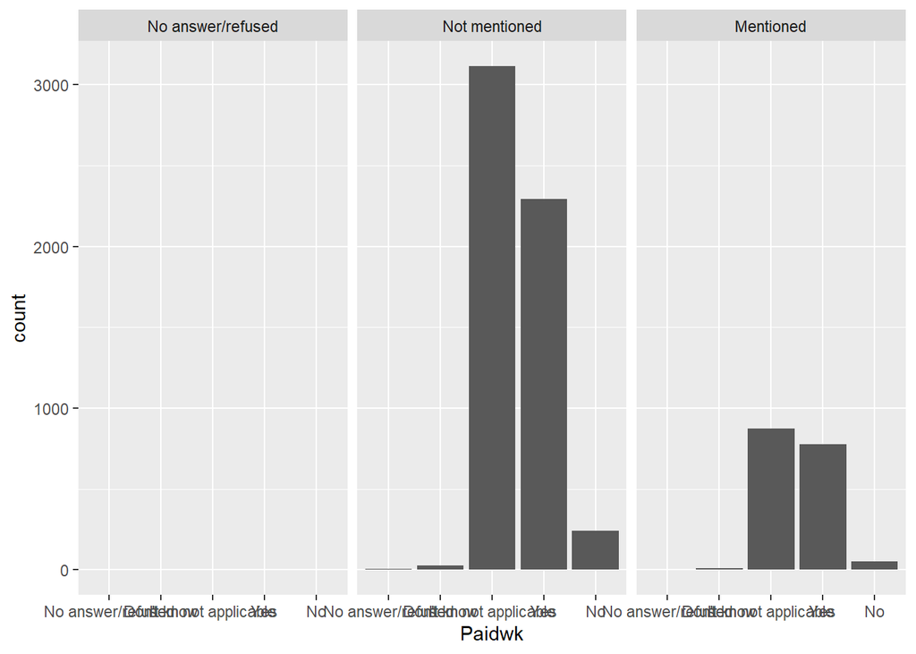

```r
# bar chart
ggplot(subset_pms07,aes(x=Paidwk))+
  geom_bar()+
  facet_grid(~Health6)
```

```r
# 2-Way Cross Tabulation
CrossTable(subset_pms07$Sex, subset_pms07$Health6)
```

```
##
##
##    Cell Contents
## |-------------------------|
## |                       N |
## | Chi-square contribution |
## |           N / Row Total |
## |           N / Col Total |
## |         N / Table Total |
## |-------------------------|
##
##
## Total Observations in Table:  7403
##
##
##                  | subset_pms07$Health6
## subset_pms07$Sex | No answer/refused |     Not mentioned |         Mentioned |         Row Total |
## -----------------|-------------------|-------------------|-------------------|-------------------|
##             Male |                 2 |              2666 |               529 |              3197 |
##                  |             0.383 |            18.043 |            60.259 |                   |
##                  |             0.001 |             0.834 |             0.165 |             0.432 |
##                  |             0.667 |             0.469 |             0.309 |                   |
##                  |             0.000 |             0.360 |             0.071 |                   |
## -----------------|-------------------|-------------------|-------------------|-------------------|
##           Female |                 1 |              3020 |              1185 |              4206 |
##                  |             0.291 |            13.715 |            45.803 |                   |
##                  |             0.000 |             0.718 |             0.282 |             0.568 |
##                  |             0.333 |             0.531 |             0.691 |                   |
##                  |             0.000 |             0.408 |             0.160 |                   |
## -----------------|-------------------|-------------------|-------------------|-------------------|
##     Column Total |                 3 |              5686 |              1714 |              7403 |
##                  |             0.000 |             0.768 |             0.232 |                   |
## -----------------|-------------------|-------------------|-------------------|-------------------|
##
##
```

```r
# 3-Way Frequency Table
# gender by ever having a paid job and mentioned
# having a mental health condition
mytable <- table(subset_pms07$Sex, subset_pms07$Paidwk,
                 subset_pms07$Health6)
ftable(mytable)
```

[output not shown]

[output cut: 33 more lines]

# 5 Severe Mental Illness

The term SMI refers to three categories of mental illness, each containing several diagnoses’, including schizophrenia, psychosis, and personality disorders. They are identified by the International Classification of Disease codes F20 through to F39 (ICD-10, 2018). For the purpose of this research, SMI will also include ‘treatment resistant’ conditions – which are usually by that point chronic and so believed to constitute SMI (Iasevoli et al., 2016). Also, of note is the exclusion (where it can be identified) of SMI when comorbid with learning disabilities, as this poses a different set of challenges

# 6 Visulisation

# 7 Non-Severe Mental Illness

# 8 Severe Mental Illness

## 8.1 Age

```r
#ggplot(subset_pms07,aes(x=Agegroup))+
#  geom_bar()+
#  facet_grid(~Sex)
```

## 8.2 Mental Health

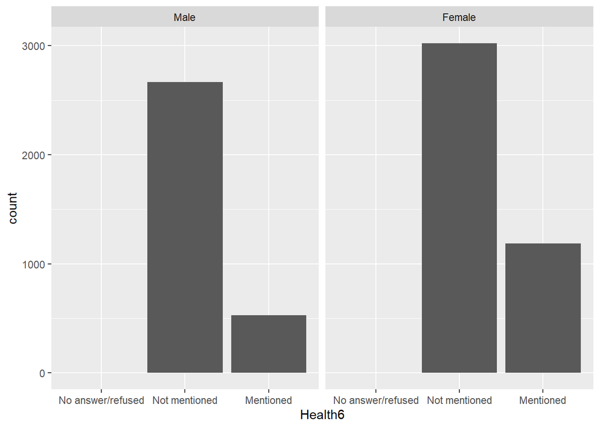

```r
ggplot(subset_pms07,aes(x=Health6))+
  geom_bar()+
  facet_grid(~Sex)
```

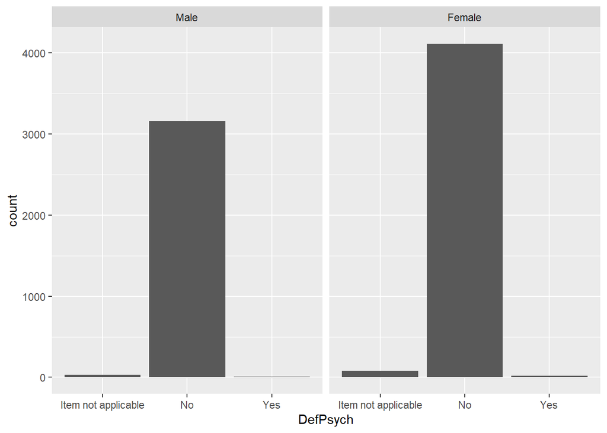

```r
# visualisation
ggplot(subset_pms07,aes(x=DefPsych))+
  geom_bar()+
  facet_grid(~Sex)
```

## 8.3 Employment

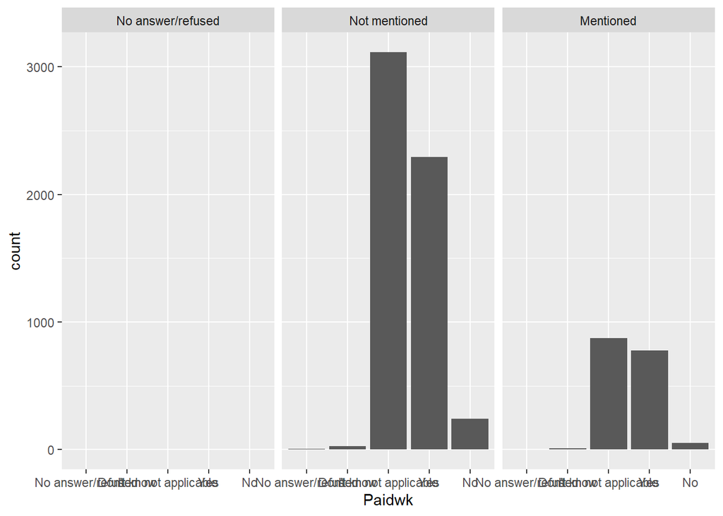

```r
# bar chart
ggplot(subset_pms07,aes(x=Paidwk))+
  geom_bar()+
  facet_grid(~Health6)
```

# 9 Tests of Independance

E.g. Test the null hypothesis whether the respondants paid job status is independent of their psychosis diagnosis at .05 significant level.

## 9.1 Chi-Sqaure

```r
# significance level.
chisq.test(subset_pms07$Paidwk, subset_pms07$DefPsych)
```

```
##
##  Pearson's Chi-squared test
##
## data:  subset_pms07$Paidwk and subset_pms07$DefPsych
## X-squared = 48.187, df = 8, p-value = 9.099e-08
```

## 9.2 Correlations

## 9.3 T-Tests

## 9.4 Futher Analysis

## 9.5 LCA

# 10 Codebook

```r
makeCodebook(subset_pms07, vol = "9",
             reportTitle = NULL, file = NULL)
```

```
## Data report generation is finished. Please wait while your output file is being rendered.
```

```
##
##  Is codebook_subset_pms079.pdf open on your computer? Please close it as fast as possible to avoid problems!
```